# Final_Churn_INN_Learner_Notebook_Full_code_cleaned

```python
print("Time taken in seconds ",end-start)
```

```
Time taken in seconds  33.70471930503845
```

**Let's plot Loss vs No. of Epochs**

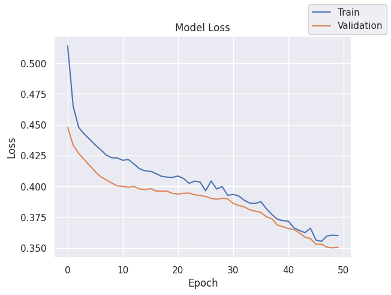

```python
plot(history_nn_with_adamdrop,'loss')
```

- The train and validation loss are going down almost same pace.

**Let's plot Recall vs No. of Epochs**

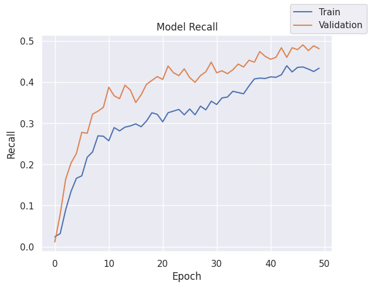

```python
plot(history_nn_with_adamdrop,'recall')
```

- The train and validation recall are increasing almost same pace with some oscillations.

**Let's print Training performance:**

```python
# Calculating different metrics on Training set
model_adamdrop_train_perf = model_performance_classification(
    model_nn_with_adam_drop, X_train, y_train
)

print("Training performance:")
model_adamdrop_train_perf
```

```
154/154 ━━━━━━━━━━━━━━━━━━━━ 0s 2ms/step
Training performance:
```

|  | Accuracy | Recall | Precision | F1 Score |
| --- | --- | --- | --- | --- |
| 0 | 0.866939 | 0.866939 | 0.86009 | 0.85297 |

**Let's print Validation performance:**

```python
# Calculating different metrics on Validtion set
model_adamdrop_val_perf = model_performance_classification(
    model_nn_with_adam_drop, X_val, y_val
)

print("Validation performance:")
model_adamdrop_val_perf
```

```
66/66 ━━━━━━━━━━━━━━━━━━━━ 0s 2ms/step
Validation performance:
```

|  | Accuracy | Recall | Precision | F1 Score |
| --- | --- | --- | --- | --- |
| 0 | 0.857143 | 0.857143 | 0.846692 | 0.845646 |

- Train Recall score of ~0.86 and validation Recall score of ~0.85 indicate consistent performance of the model between training and validation datasets while calculating using weighted average.

**Classification report**

```python
#Predicting the results using best as a threshold
y_train_pred = model_nn_with_adam_drop.predict(X_train)
y_train_pred = (y_train_pred > 0.5)

#Classification report on train set
cr_nn_with_adam_drop_train = classification_report(y_train, y_train_pred)
print(cr_nn_with_adam_drop_train)
```

```
154/154 ━━━━━━━━━━━━━━━━━━━━ 0s 1ms/step
              precision    recall  f1-score   support

           0       0.88      0.97      0.92      3902
           1       0.80      0.47      0.59       998

    accuracy                           0.87      4900
   macro avg       0.84      0.72      0.75      4900
weighted avg       0.86      0.87      0.85      4900
```

```python
#Predicting the results using best as a threshold
y_val_pred = model_nn_with_adam_drop.predict(X_val)
y_val_pred = (y_val_pred > 0.5)

#Classification report on validation set
cr_nn_with_adam_drop_val = classification_report(y_val, y_val_pred)
print(cr_nn_with_adam_drop_val)
```

```
66/66 ━━━━━━━━━━━━━━━━━━━━ 0s 1ms/step
              precision    recall  f1-score   support

           0       0.88      0.95      0.91      1672
           1       0.73      0.48      0.58       428

    accuracy                           0.86      2100
   macro avg       0.80      0.72      0.75      2100
weighted avg       0.85      0.86      0.85      2100
```

**Observations**

- For class 0, Train and validaiton recall is .97 and .95 respectively and well generalize
- For Class 1, Train and validaiton recall is .47 and .48 respectively and shows generalize.
- Model seems much Bias towards Class 0 while predecting and therefore recall for class 1 is very less.

```python
model_name = "Neural Netowrk with Adam & Dropout"

train_metric_df.loc[model_name] = recall_score(y_train,y_train_pred)
valid_metric_df.loc[model_name] = recall_score(y_val,y_val_pred)
```

**Let's print the Confusion matrix**

```
154/154 ━━━━━━━━━━━━━━━━━━━━ 0s 1ms/step
```

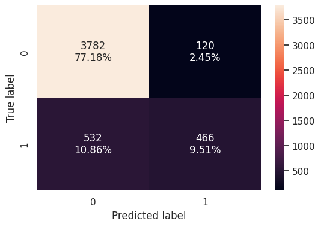

```python
# print confusion matrix on train set
plot_confusion_matrix(model_nn_with_adam_drop, X_train, y_train)
```

```
66/66 ━━━━━━━━━━━━━━━━━━━━ 0s 1ms/step
```

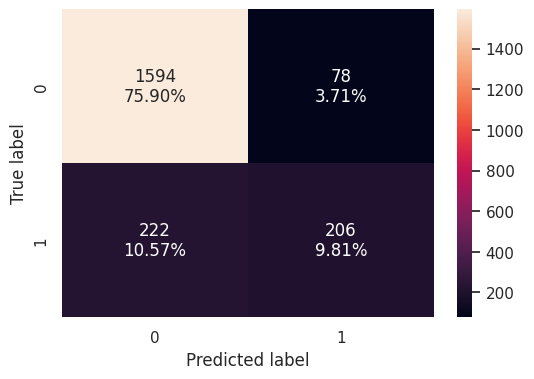

```python
# print confusion matrix on validation set
plot_confusion_matrix(model_nn_with_adam_drop, X_val, y_val)
```

### Neural Network with Balanced Data (by applying SMOTE) and SGD Optimizer

**Let's try to apply SMOTE to balance this dataset and then again apply hyperparamter tuning accordingly.**

```python
# Defining the batch size and # epochs upfront as we'll be using the same values for all models
epochs = 50
batch_size = 32
```

```python
# clears the current Keras session, resetting all layers and models previously created, freeing up memory and resources.
backend.clear_session()
```

```python
# Fixing the seed for random number generators
np.random.seed(2)

random.seed(2)

tf.random.set_seed(2)
```

- Let's start with a neural network consisting of
  - One Input layer with 32 neurons respectively
  - Two hidden layers 16 and 8 neurons respectively
  - Activation function of ReLU.
  - SGD as the optimizer with learning_rate=0.001
  - Using Oversampled data set for training

```python
#Initializing the neural network
model_nn_with_sgd_smote = Sequential()

# Adding the first input layer with 32 neurons and relu as activation function
model_nn_with_sgd_smote.add(Dense(32, activation='relu', input_dim = X_train_smote.shape[1]))

# Adding the second input layer with 16 neurons and relu as activation function
model_nn_with_sgd_smote.add(Dense(16, activation='relu'))

# Adding the third input layer with 8 neurons and relu as activation function
model_nn_with_sgd_smote.add(Dense(8, activation='relu'))

# Adding the output input layer sigmoid as activation function
model_nn_with_sgd_smote.add(Dense(1, activation = 'sigmoid'))
```

Let's print the summary of the model

```python
#Printing the summary.
model_nn_with_sgd_smote.summary()
```

```
Model: "sequential"
```

```
┏━━━━━━━━━━━━━━━━━━━━━━━━━━━━━━━━━━━━━━┳━━━━━━━━━━━━━━━━━━━━━━━━━━━━━┳━━━━━━━━━━━━━━━━━┓
┃ Layer (type)                         ┃ Output Shape                ┃         Param # ┃
┡━━━━━━━━━━━━━━━━━━━━━━━━━━━━━━━━━━━━━━╇━━━━━━━━━━━━━━━━━━━━━━━━━━━━━╇━━━━━━━━━━━━━━━━━┩
│ dense (Dense)                        │ (None, 32)                  │             384 │
├──────────────────────────────────────┼─────────────────────────────┼─────────────────┤
│ dense_1 (Dense)                      │ (None, 16)                  │             528 │
├──────────────────────────────────────┼─────────────────────────────┼─────────────────┤
│ dense_2 (Dense)                      │ (None, 8)                   │             136 │
├──────────────────────────────────────┼─────────────────────────────┼─────────────────┤
│ dense_3 (Dense)                      │ (None, 1)                   │               9 │
└──────────────────────────────────────┴─────────────────────────────┴─────────────────┘
```

```
 Total params: 1,057 (4.13 KB)
```

```
 Trainable params: 1,057 (4.13 KB)
```

```
 Non-trainable params: 0 (0.00 B)
```

```python
#Create an instance for SGD as the optimizer.
optimizer = tf.keras.optimizers.SGD(learning_rate=0.001)
```

```python
# Compile the model
model_nn_with_sgd_smote.compile(loss='binary_crossentropy', optimizer=optimizer, metrics=['recall'])
```

```python
# Now let's train the model using the below piece of code. We will use validation set for Validation.
start = time.time()
history_nn_with_sgdsmote = model_nn_with_sgd_smote.fit(
    X_train_smote, y_train_smote,
    batch_size=batch_size,
    validation_data=(X_val,y_val),
    epochs=epochs,
    verbose=1
)
end=time.time()
```

```
244/244 ━━━━━━━━━━━━━━━━━━━━ 3s 6ms/step - loss: 0.7009 - recall: 0.9467 - val_loss: 0.7266 - val_recall: 0.9299
244/244 ━━━━━━━━━━━━━━━━━━━━ 1s 2ms/step - loss: 0.6978 - recall: 0.9273 - val_loss: 0.7176 - val_recall: 0.9065
244/244 ━━━━━━━━━━━━━━━━━━━━ 1s 2ms/step - loss: 0.6947 - recall: 0.9061 - val_loss: 0.7092 - val_recall: 0.8598
244/244 ━━━━━━━━━━━━━━━━━━━━ 1s 2ms/step - loss: 0.6917 - recall: 0.8669 - val_loss: 0.7012 - val_recall: 0.8154
244/244 ━━━━━━━━━━━━━━━━━━━━ 0s 2ms/step - loss: 0.6888 - recall: 0.8286 - val_loss: 0.6941 - val_recall: 0.7874
244/244 ━━━━━━━━━━━━━━━━━━━━ 1s 2ms/step - loss: 0.6861 - recall: 0.7910 - val_loss: 0.6878 - val_recall: 0.7453
244/244 ━━━━━━━━━━━━━━━━━━━━ 1s 2ms/step - loss: 0.6836 - recall: 0.7724 - val_loss: 0.6822 - val_recall: 0.7290
244/244 ━━━━━━━━━━━━━━━━━━━━ 1s 3ms/step - loss: 0.6813 - recall: 0.7553 - val_loss: 0.6771 - val_recall: 0.7196
244/244 ━━━━━━━━━━━━━━━━━━━━ 1s 3ms/step - loss: 0.6790 - recall: 0.7368 - val_loss: 0.6724 - val_recall: 0.7033
244/244 ━━━━━━━━━━━━━━━━━━━━ 1s 3ms/step - loss: 0.6769 - recall: 0.7253 - val_loss: 0.6680 - val_recall: 0.6893
244/244 ━━━━━━━━━━━━━━━━━━━━ 1s 3ms/step - loss: 0.6747 - recall: 0.7198 - val_loss: 0.6638 - val_recall: 0.6799
244/244 ━━━━━━━━━━━━━━━━━━━━ 1s 2ms/step - loss: 0.6726 - recall: 0.7178 - val_loss: 0.6599 - val_recall: 0.6706
244/244 ━━━━━━━━━━━━━━━━━━━━ 1s 2ms/step - loss: 0.6705 - recall: 0.7153 - val_loss: 0.6559 - val_recall: 0.6636
244/244 ━━━━━━━━━━━━━━━━━━━━ 0s 2ms/step - loss: 0.6684 - recall: 0.7103 - val_loss: 0.6522 - val_recall: 0.6612
244/244 ━━━━━━━━━━━━━━━━━━━━ 1s 2ms/step - loss: 0.6663 - recall: 0.7053 - val_loss: 0.6487 - val_recall: 0.6519
244/244 ━━━━━━━━━━━━━━━━━━━━ 1s 2ms/step - loss: 0.6643 - recall: 0.7016 - val_loss: 0.6454 - val_recall: 0.6449
244/244 ━━━━━━━━━━━━━━━━━━━━ 1s 2ms/step - loss: 0.6622 - recall: 0.6953 - val_loss: 0.6422 - val_recall: 0.6449
244/244 ━━━━━━━━━━━━━━━━━━━━ 0s 2ms/step - loss: 0.6601 - recall: 0.6918 - val_loss: 0.6392 - val_recall: 0.6425
244/244 ━━━━━━━━━━━━━━━━━━━━ 1s 2ms/step - loss: 0.6581 - recall: 0.6915 - val_loss: 0.6362 - val_recall: 0.6425
244/244 ━━━━━━━━━━━━━━━━━━━━ 0s 2ms/step - loss: 0.6560 - recall: 0.6909 - val_loss: 0.6334 - val_recall: 0.6402
244/244 ━━━━━━━━━━━━━━━━━━━━ 0s 2ms/step - loss: 0.6539 - recall: 0.6902 - val_loss: 0.6307 - val_recall: 0.6449
244/244 ━━━━━━━━━━━━━━━━━━━━ 1s 2ms/step - loss: 0.6518 - recall: 0.6906 - val_loss: 0.6281 - val_recall: 0.6495
244/244 ━━━━━━━━━━━━━━━━━━━━ 1s 2ms/step - loss: 0.6496 - recall: 0.6895 - val_loss: 0.6255 - val_recall: 0.6472
244/244 ━━━━━━━━━━━━━━━━━━━━ 1s 2ms/step - loss: 0.6475 - recall: 0.6916 - val_loss: 0.6232 - val_recall: 0.6565
244/244 ━━━━━━━━━━━━━━━━━━━━ 1s 2ms/step - loss: 0.6453 - recall: 0.6912 - val_loss: 0.6209 - val_recall: 0.6612
244/244 ━━━━━━━━━━━━━━━━━━━━ 1s 2ms/step - loss: 0.6432 - recall: 0.6870 - val_loss: 0.6187 - val_recall: 0.6682
244/244 ━━━━━━━━━━━━━━━━━━━━ 1s 2ms/step - loss: 0.6410 - recall: 0.6896 - val_loss: 0.6166 - val_recall: 0.6682
244/244 ━━━━━━━━━━━━━━━━━━━━ 1s 2ms/step - loss: 0.6387 - recall: 0.6915 - val_loss: 0.6145 - val_recall: 0.6729
244/244 ━━━━━━━━━━━━━━━━━━━━ 1s 3ms/step - loss: 0.6365 - recall: 0.6925 - val_loss: 0.6126 - val_recall: 0.6799
244/244 ━━━━━━━━━━━━━━━━━━━━ 1s 3ms/step - loss: 0.6342 - recall: 0.6928 - val_loss: 0.6107 - val_recall: 0.6846
244/244 ━━━━━━━━━━━━━━━━━━━━ 1s 3ms/step - loss: 0.6320 - recall: 0.6969 - val_loss: 0.6090 - val_recall: 0.6869
244/244 ━━━━━━━━━━━━━━━━━━━━ 1s 2ms/step - loss: 0.6297 - recall: 0.6964 - val_loss: 0.6074 - val_recall: 0.6939
244/244 ━━━━━━━━━━━━━━━━━━━━ 1s 2ms/step - loss: 0.6274 - recall: 0.6993 - val_loss: 0.6057 - val_recall: 0.7079
244/244 ━━━━━━━━━━━━━━━━━━━━ 0s 2ms/step - loss: 0.6251 - recall: 0.7053 - val_loss: 0.6041 - val_recall: 0.7103
244/244 ━━━━━━━━━━━━━━━━━━━━ 0s 2ms/step - loss: 0.6229 - recall: 0.7097 - val_loss: 0.6025 - val_recall: 0.7126
244/244 ━━━━━━━━━━━━━━━━━━━━ 1s 2ms/step - loss: 0.6206 - recall: 0.7125 - val_loss: 0.6010 - val_recall: 0.7150
244/244 ━━━━━━━━━━━━━━━━━━━━ 1s 2ms/step - loss: 0.6184 - recall: 0.7164 - val_loss: 0.5996 - val_recall: 0.7173
244/244 ━━━━━━━━━━━━━━━━━━━━ 1s 2ms/step - loss: 0.6163 - recall: 0.7190 - val_loss: 0.5982 - val_recall: 0.7173
244/244 ━━━━━━━━━━━━━━━━━━━━ 0s 2ms/step - loss: 0.6141 - recall: 0.7208 - val_loss: 0.5968 - val_recall: 0.7173
244/244 ━━━━━━━━━━━━━━━━━━━━ 0s 2ms/step - loss: 0.6120 - recall: 0.7250 - val_loss: 0.5955 - val_recall: 0.7196
244/244 ━━━━━━━━━━━━━━━━━━━━ 0s 2ms/step - loss: 0.6099 - recall: 0.7259 - val_loss: 0.5941 - val_recall: 0.7243
244/244 ━━━━━━━━━━━━━━━━━━━━ 1s 2ms/step - loss: 0.6078 - recall: 0.7238 - val_loss: 0.5928 - val_recall: 0.7243
244/244 ━━━━━━━━━━━━━━━━━━━━ 1s 2ms/step - loss: 0.6058 - recall: 0.7262 - val_loss: 0.5915 - val_recall: 0.7243
244/244 ━━━━━━━━━━━━━━━━━━━━ 1s 2ms/step - loss: 0.6038 - recall: 0.7235 - val_loss: 0.5904 - val_recall: 0.7243
244/244 ━━━━━━━━━━━━━━━━━━━━ 1s 2ms/step - loss: 0.6019 - recall: 0.7233 - val_loss: 0.5893 - val_recall: 0.7220
244/244 ━━━━━━━━━━━━━━━━━━━━ 1s 2ms/step - loss: 0.6000 - recall: 0.7272 - val_loss: 0.5883 - val_recall: 0.7220
244/244 ━━━━━━━━━━━━━━━━━━━━ 1s 2ms/step - loss: 0.5982 - recall: 0.7283 - val_loss: 0.5874 - val_recall: 0.7220
244/244 ━━━━━━━━━━━━━━━━━━━━ 1s 2ms/step - loss: 0.5965 - recall: 0.7300 - val_loss: 0.5867 - val_recall: 0.7290
244/244 ━━━━━━━━━━━━━━━━━━━━ 1s 2ms/step - loss: 0.5948 - recall: 0.7301 - val_loss: 0.5859 - val_recall: 0.7266
244/244 ━━━━━━━━━━━━━━━━━━━━ 1s 2ms/step - loss: 0.5931 - recall: 0.7304 - val_loss: 0.5851 - val_recall: 0.7313
```

```python
print("Time taken in seconds ",end-start)
```

```
Time taken in seconds  33.501389503479004
```

**Let's plot Loss vs No. of Epochs**

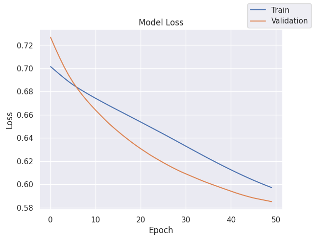

```python
plot(history_nn_with_sgdsmote,'loss')
```

- The train and validation loss are going down at almost same pace with maintaning some divergence.

**Let's plot Recall vs No. of Epochs**

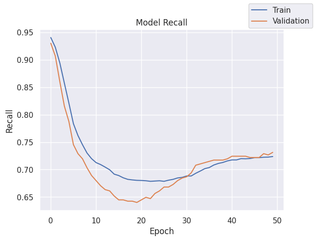

```python
plot(history_nn_with_sgdsmote,'recall')
```

**Let's print Training performance:**

```python
# Calculating different metrics on train set
model_sgdsmote_train_perf = model_performance_classification(
    model_nn_with_sgd_smote, X_train_smote, y_train_smote
)
print("Training performance:")
model_sgdsmote_train_perf
```

```
244/244 ━━━━━━━━━━━━━━━━━━━━ 1s 2ms/step
Training performance:
```

|  | Accuracy | Recall | Precision | F1 Score |
| --- | --- | --- | --- | --- |
| 0 | 0.694516 | 0.694516 | 0.695136 | 0.694273 |

**Let's print Validation performance:**

```python
# Calculating different metrics on Validation set
model_sgdsmote_val_perf = model_performance_classification(
    model_nn_with_sgd_smote, X_val, y_val
)
print("Validation performance:")
model_sgdsmote_val_perf
```

```
66/66 ━━━━━━━━━━━━━━━━━━━━ 0s 3ms/step
Validation performance:
```

|  | Accuracy | Recall | Precision | F1 Score |
| --- | --- | --- | --- | --- |
| 0 | 0.678571 | 0.678571 | 0.79464 | 0.708873 |

- Train Recall score of ~0.69 and validation Recall score of ~0.67 indicate consistent performance of the model between training and validation datasets while calculating using weighted average.

**Classification Report**

```python
#Predicting the results using best as a threshold
y_train_pred = model_nn_with_sgd_smote.predict(X_train_smote)
y_train_pred = (y_train_pred > 0.5)

#Classification report on train set
cr_nn_with_sdg_smote_train = classification_report(y_train_smote, y_train_pred)
print(cr_nn_with_sdg_smote_train)
```

```
244/244 ━━━━━━━━━━━━━━━━━━━━ 0s 2ms/step
              precision    recall  f1-score   support

           0       0.71      0.67      0.69      3902
           1       0.68      0.72      0.70      3902

    accuracy                           0.69      7804
   macro avg       0.70      0.69      0.69      7804
weighted avg       0.70      0.69      0.69      7804
```

```python
#Predicting the results using best as a threshold
y_val_pred = model_nn_with_sgd_smote.predict(X_val)
y_val_pred = (y_val_pred > 0.5)

#Classification report on validation set
cr_nn_with_sdg_smote_val = classification_report(y_val, y_val_pred)
print(cr_nn_with_sdg_smote_val)
```

```
66/66 ━━━━━━━━━━━━━━━━━━━━ 0s 1ms/step
              precision    recall  f1-score   support

           0       0.91      0.67      0.77      1672
           1       0.36      0.73      0.48       428

    accuracy                           0.68      2100
   macro avg       0.63      0.70      0.62      2100
weighted avg       0.79      0.68      0.71      2100
```

```python
model_name = "Neural Netowrk with SMOTE and SGD"

train_metric_df.loc[model_name] = recall_score(y_train_smote,y_train_pred)
valid_metric_df.loc[model_name] = recall_score(y_val,y_val_pred)
```

**Observations**

- For class 0, Train and validaiton recall is .67 and .67 respectively and well generalize
- For Class 1, Train and validaiton recall is .72 and .73 respectively and well generalize.
- Model is well generalize for predecting both recall for both classes.

**Let's print the Confusion matrix**

```
244/244 ━━━━━━━━━━━━━━━━━━━━ 0s 1ms/step
```

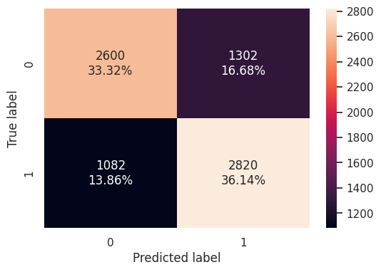

```python
# print confusion matrix on train set
plot_confusion_matrix(model_nn_with_sgd_smote, X_train_smote, y_train_smote)
```

```
66/66 ━━━━━━━━━━━━━━━━━━━━ 0s 1ms/step
```

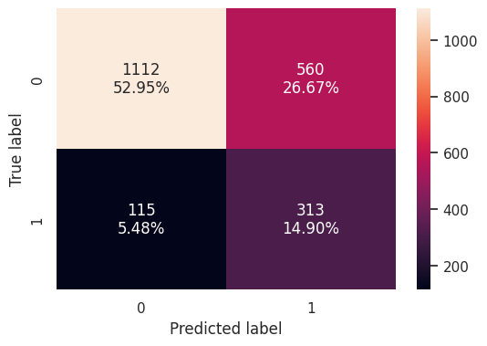

```python
# print confusion matrix on validation set
plot_confusion_matrix(model_nn_with_sgd_smote, X_val, y_val)
```

### Neural Network with Balanced Data (by applying SMOTE) and Adam Optimizer

```python
# Defining the batch size and # epochs upfront as we'll be using the same values for all models
epochs = 50
batch_size = 64
```

```python
# clears the current Keras session, resetting all layers and models previously created, freeing up memory and resources.
backend.clear_session()
```

```python
# Fixing the seed for random number generators
np.random.seed(2)

random.seed(2)

tf.random.set_seed(2)
```

- Let's start with a neural network consisting of
  - One Input layer with 32 neurons
  - Two hidden layers with 16 and 8 neurons respectively
  - Activation function of ReLU.
  - Adam as the optimizer with learning_rate=0.001
  - Using Oversampled data set for training

```python
#Initializing the neural network
model_nn_with_adam_smote = Sequential()

# Adding the first input layer with 32 neurons and relu as activation function
model_nn_with_adam_smote.add(Dense(32, activation='relu', input_dim = X_train_smote.shape[1]))

# Adding the second input layer with 16 neurons and relu as activation function
model_nn_with_adam_smote.add(Dense(16, activation='relu'))

# Adding the second input layer with 8 neurons and relu as activation function
model_nn_with_adam_smote.add(Dense(8, activation='relu'))

# Adding the output input layer sigmoid as activation function
model_nn_with_adam_smote.add(Dense(1, activation = 'sigmoid'))
```

Let's print the summary of the model

```python
#Printing the summary.
model_nn_with_adam_smote.summary()
```

```
Model: "sequential"
```

```
┏━━━━━━━━━━━━━━━━━━━━━━━━━━━━━━━━━━━━━━┳━━━━━━━━━━━━━━━━━━━━━━━━━━━━━┳━━━━━━━━━━━━━━━━━┓
┃ Layer (type)                         ┃ Output Shape                ┃         Param # ┃
┡━━━━━━━━━━━━━━━━━━━━━━━━━━━━━━━━━━━━━━╇━━━━━━━━━━━━━━━━━━━━━━━━━━━━━╇━━━━━━━━━━━━━━━━━┩
│ dense (Dense)                        │ (None, 32)                  │             384 │
├──────────────────────────────────────┼─────────────────────────────┼─────────────────┤
│ dense_1 (Dense)                      │ (None, 16)                  │             528 │
├──────────────────────────────────────┼─────────────────────────────┼─────────────────┤
│ dense_2 (Dense)                      │ (None, 8)                   │             136 │
├──────────────────────────────────────┼─────────────────────────────┼─────────────────┤
│ dense_3 (Dense)                      │ (None, 1)                   │               9 │
└──────────────────────────────────────┴─────────────────────────────┴─────────────────┘
```

```
 Total params: 1,057 (4.13 KB)
```

```
 Trainable params: 1,057 (4.13 KB)
```

```
 Non-trainable params: 0 (0.00 B)
```

```python
#Create an instance for Adam as the optimizer.
optimizer = tf.keras.optimizers.Adam(learning_rate=0.001)
```

```python
# Compile the model
model_nn_with_adam_smote.compile(loss='binary_crossentropy', optimizer=optimizer, metrics=['recall'])
```

```python
# Now let's train the model using the below piece of code. We will use validation set for Validation.
start = time.time()
history_nn_with_adamsmote = model_nn_with_adam_smote.fit(
    X_train_smote, y_train_smote,
    batch_size=batch_size,
    validation_data=(X_val,y_val),
    epochs=epochs,
    verbose=1
)
end=time.time()
```

```
122/122 ━━━━━━━━━━━━━━━━━━━━ 4s 14ms/step - loss: 0.6674 - recall: 0.8052 - val_loss: 0.5542 - val_recall: 0.6636
122/122 ━━━━━━━━━━━━━━━━━━━━ 0s 2ms/step - loss: 0.5746 - recall: 0.7170 - val_loss: 0.5390 - val_recall: 0.6916
122/122 ━━━━━━━━━━━━━━━━━━━━ 0s 2ms/step - loss: 0.5539 - recall: 0.7260 - val_loss: 0.5340 - val_recall: 0.6963
122/122 ━━━━━━━━━━━━━━━━━━━━ 0s 2ms/step - loss: 0.5433 - recall: 0.7281 - val_loss: 0.5309 - val_recall: 0.6916
122/122 ━━━━━━━━━━━━━━━━━━━━ 1s 2ms/step - loss: 0.5346 - recall: 0.7277 - val_loss: 0.5253 - val_recall: 0.6893
122/122 ━━━━━━━━━━━━━━━━━━━━ 0s 2ms/step - loss: 0.5272 - recall: 0.7241 - val_loss: 0.5261 - val_recall: 0.6869
122/122 ━━━━━━━━━━━━━━━━━━━━ 0s 2ms/step - loss: 0.5197 - recall: 0.7258 - val_loss: 0.5247 - val_recall: 0.6729
122/122 ━━━━━━━━━━━━━━━━━━━━ 0s 2ms/step - loss: 0.5137 - recall: 0.7231 - val_loss: 0.5216 - val_recall: 0.6565
122/122 ━━━━━━━━━━━━━━━━━━━━ 0s 2ms/step - loss: 0.5086 - recall: 0.7234 - val_loss: 0.5197 - val_recall: 0.6519
122/122 ━━━━━━━━━━━━━━━━━━━━ 0s 2ms/step - loss: 0.5040 - recall: 0.7255 - val_loss: 0.5191 - val_recall: 0.6449
122/122 ━━━━━━━━━━━━━━━━━━━━ 0s 2ms/step - loss: 0.4992 - recall: 0.7255 - val_loss: 0.5159 - val_recall: 0.6425
122/122 ━━━━━━━━━━━━━━━━━━━━ 0s 2ms/step - loss: 0.4951 - recall: 0.7293 - val_loss: 0.5150 - val_recall: 0.6495
122/122 ━━━━━━━━━━━━━━━━━━━━ 0s 2ms/step - loss: 0.4906 - recall: 0.7305 - val_loss: 0.5120 - val_recall: 0.6402
122/122 ━━━━━━━━━━━━━━━━━━━━ 0s 4ms/step - loss: 0.4851 - recall: 0.7301 - val_loss: 0.5055 - val_recall: 0.6355
122/122 ━━━━━━━━━━━━━━━━━━━━ 1s 3ms/step - loss: 0.4790 - recall: 0.7373 - val_loss: 0.4996 - val_recall: 0.6425
122/122 ━━━━━━━━━━━━━━━━━━━━ 1s 3ms/step - loss: 0.4721 - recall: 0.7430 - val_loss: 0.4911 - val_recall: 0.6472
122/122 ━━━━━━━━━━━━━━━━━━━━ 0s 3ms/step - loss: 0.4652 - recall: 0.7388 - val_loss: 0.4852 - val_recall: 0.6402
122/122 ━━━━━━━━━━━━━━━━━━━━ 1s 4ms/step - loss: 0.4580 - recall: 0.7487 - val_loss: 0.4835 - val_recall: 0.6472
122/122 ━━━━━━━━━━━━━━━━━━━━ 1s 3ms/step - loss: 0.4511 - recall: 0.7549 - val_loss: 0.4773 - val_recall: 0.6565
122/122 ━━━━━━━━━━━━━━━━━━━━ 0s 3ms/step - loss: 0.4448 - recall: 0.7615 - val_loss: 0.4735 - val_recall: 0.6589
122/122 ━━━━━━━━━━━━━━━━━━━━ 0s 2ms/step - loss: 0.4386 - recall: 0.7662 - val_loss: 0.4711 - val_recall: 0.6636
122/122 ━━━━━━━━━━━━━━━━━━━━ 0s 2ms/step - loss: 0.4328 - recall: 0.7713 - val_loss: 0.4687 - val_recall: 0.6752
122/122 ━━━━━━━━━━━━━━━━━━━━ 0s 2ms/step - loss: 0.4277 - recall: 0.7771 - val_loss: 0.4632 - val_recall: 0.6776
122/122 ━━━━━━━━━━━━━━━━━━━━ 0s 2ms/step - loss: 0.4230 - recall: 0.7799 - val_loss: 0.4606 - val_recall: 0.6729
122/122 ━━━━━━━━━━━━━━━━━━━━ 0s 2ms/step - loss: 0.4191 - recall: 0.7785 - val_loss: 0.4636 - val_recall: 0.6636
122/122 ━━━━━━━━━━━━━━━━━━━━ 0s 2ms/step - loss: 0.4150 - recall: 0.7842 - val_loss: 0.4634 - val_recall: 0.6636
122/122 ━━━━━━━━━━━━━━━━━━━━ 0s 2ms/step - loss: 0.4112 - recall: 0.7894 - val_loss: 0.4635 - val_recall: 0.6682
122/122 ━━━━━━━━━━━━━━━━━━━━ 0s 2ms/step - loss: 0.4081 - recall: 0.7920 - val_loss: 0.4635 - val_recall: 0.6729
122/122 ━━━━━━━━━━━━━━━━━━━━ 0s 2ms/step - loss: 0.4052 - recall: 0.7932 - val_loss: 0.4631 - val_recall: 0.6729
122/122 ━━━━━━━━━━━━━━━━━━━━ 0s 2ms/step - loss: 0.4025 - recall: 0.7951 - val_loss: 0.4656 - val_recall: 0.6822
122/122 ━━━━━━━━━━━━━━━━━━━━ 0s 2ms/step - loss: 0.3995 - recall: 0.7962 - val_loss: 0.4683 - val_recall: 0.6822
122/122 ━━━━━━━━━━━━━━━━━━━━ 0s 2ms/step - loss: 0.3967 - recall: 0.8026 - val_loss: 0.4667 - val_recall: 0.6752
122/122 ━━━━━━━━━━━━━━━━━━━━ 0s 2ms/step - loss: 0.3944 - recall: 0.8081 - val_loss: 0.4683 - val_recall: 0.6752
122/122 ━━━━━━━━━━━━━━━━━━━━ 0s 2ms/step - loss: 0.3922 - recall: 0.8115 - val_loss: 0.4677 - val_recall: 0.6752
122/122 ━━━━━━━━━━━━━━━━━━━━ 0s 2ms/step - loss: 0.3898 - recall: 0.8132 - val_loss: 0.4697 - val_recall: 0.6799
122/122 ━━━━━━━━━━━━━━━━━━━━ 0s 2ms/step - loss: 0.3877 - recall: 0.8117 - val_loss: 0.4695 - val_recall: 0.6869
122/122 ━━━━━━━━━━━━━━━━━━━━ 0s 2ms/step - loss: 0.3857 - recall: 0.8146 - val_loss: 0.4725 - val_recall: 0.6822
122/122 ━━━━━━━━━━━━━━━━━━━━ 0s 2ms/step - loss: 0.3835 - recall: 0.8169 - val_loss: 0.4715 - val_recall: 0.6822
122/122 ━━━━━━━━━━━━━━━━━━━━ 0s 2ms/step - loss: 0.3817 - recall: 0.8188 - val_loss: 0.4711 - val_recall: 0.6799
122/122 ━━━━━━━━━━━━━━━━━━━━ 0s 2ms/step - loss: 0.3798 - recall: 0.8222 - val_loss: 0.4713 - val_recall: 0.6752
122/122 ━━━━━━━━━━━━━━━━━━━━ 0s 2ms/step - loss: 0.3783 - recall: 0.8248 - val_loss: 0.4728 - val_recall: 0.6799
122/122 ━━━━━━━━━━━━━━━━━━━━ 0s 2ms/step - loss: 0.3764 - recall: 0.8269 - val_loss: 0.4723 - val_recall: 0.6776
122/122 ━━━━━━━━━━━━━━━━━━━━ 0s 2ms/step - loss: 0.3748 - recall: 0.8280 - val_loss: 0.4753 - val_recall: 0.6799
122/122 ━━━━━━━━━━━━━━━━━━━━ 0s 2ms/step - loss: 0.3729 - recall: 0.8290 - val_loss: 0.4750 - val_recall: 0.6776
122/122 ━━━━━━━━━━━━━━━━━━━━ 0s 2ms/step - loss: 0.3712 - recall: 0.8309 - val_loss: 0.4755 - val_recall: 0.6752
122/122 ━━━━━━━━━━━━━━━━━━━━ 0s 2ms/step - loss: 0.3697 - recall: 0.8308 - val_loss: 0.4773 - val_recall: 0.6729
122/122 ━━━━━━━━━━━━━━━━━━━━ 0s 2ms/step - loss: 0.3678 - recall: 0.8326 - val_loss: 0.4771 - val_recall: 0.6752
122/122 ━━━━━━━━━━━━━━━━━━━━ 0s 2ms/step - loss: 0.3666 - recall: 0.8322 - val_loss: 0.4775 - val_recall: 0.6752
122/122 ━━━━━━━━━━━━━━━━━━━━ 0s 2ms/step - loss: 0.3646 - recall: 0.8365 - val_loss: 0.4796 - val_recall: 0.6752
122/122 ━━━━━━━━━━━━━━━━━━━━ 1s 2ms/step - loss: 0.3633 - recall: 0.8376 - val_loss: 0.4823 - val_recall: 0.6752
```

```python
print("Time taken in seconds ",end-start)
```

```
Time taken in seconds  20.6537766456604
```

**Let's plot Loss vs No. of Epochs**

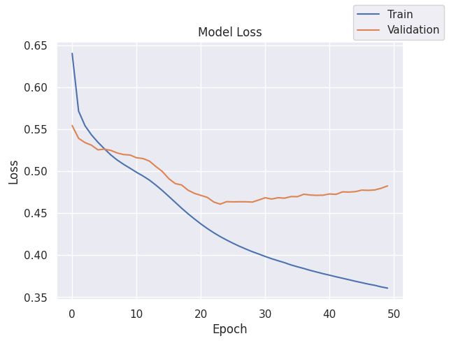

```python
plot(history_nn_with_adamsmote,'loss')
```

- The validation loss stop going down after 22th epochs

**Let's plot Recall vs No. of Epochs**

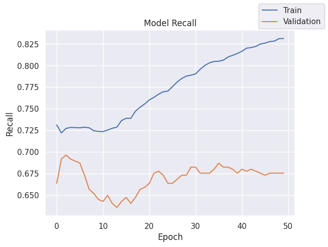

```python
plot(history_nn_with_adamsmote,'recall')
```

- Validation Recall starts going up after 15th epochs but no near by Train recall.

**Let's print Training performance:**

```python
# Calculating different metrics on train set
model_adamsmote_train_perf = model_performance_classification(
    model_nn_with_adam_smote, X_train_smote, y_train_smote
)
print("Training performance:")
model_adamsmote_train_perf
```

```
244/244 ━━━━━━━━━━━━━━━━━━━━ 1s 2ms/step
Training performance:
```

|  | Accuracy | Recall | Precision | F1 Score |
| --- | --- | --- | --- | --- |
| 0 | 0.845464 | 0.845464 | 0.84578 | 0.845429 |

**Let's print Validation performance:**

```python
# Calculating different metrics on Validation set
model_adamsmote_val_perf = model_performance_classification(
    model_nn_with_adam_smote, X_val, y_val
)
print("Validation performance:")
model_adamsmote_val_perf
```

```
66/66 ━━━━━━━━━━━━━━━━━━━━ 0s 3ms/step
Validation performance:
```

|  | Accuracy | Recall | Precision | F1 Score |
| --- | --- | --- | --- | --- |
| 0 | 0.783333 | 0.783333 | 0.81952 | 0.795841 |

- Train Recall score of ~0.84 and validation Recall score of ~0.78 indicate consistent performance of the model between training and validation datasets while calculating using weighted average.

**Classification Report**

```python
#Predicting the results using best as a threshold
y_train_pred = model_nn_with_adam_smote.predict(X_train_smote)
y_train_pred = (y_train_pred > 0.5)

#Classification report on train set
cr_nn_with_adam_smote_train = classification_report(y_train_smote, y_train_pred)
print(cr_nn_with_adam_smote_train)
```

```
244/244 ━━━━━━━━━━━━━━━━━━━━ 1s 2ms/step
              precision    recall  f1-score   support

           0       0.84      0.86      0.85      3902
           1       0.86      0.83      0.84      3902

    accuracy                           0.85      7804
   macro avg       0.85      0.85      0.85      7804
weighted avg       0.85      0.85      0.85      7804
```

```python
#Predicting the results using best as a threshold
y_val_pred = model_nn_with_adam_smote.predict(X_val)
y_val_pred = (y_val_pred > 0.5)

#Classification report on validation set
cr_nn_with_adam_smote_val = classification_report(y_val, y_val_pred)
print(cr_nn_with_adam_smote_val)
```

```
66/66 ━━━━━━━━━━━━━━━━━━━━ 0s 1ms/step
              precision    recall  f1-score   support

           0       0.91      0.81      0.86      1672
           1       0.48      0.68      0.56       428

    accuracy                           0.78      2100
   macro avg       0.69      0.74      0.71      2100
weighted avg       0.82      0.78      0.80      2100
```

```python
model_name = "Neural Netowrk with SMOTE and Adam"

train_metric_df.loc[model_name] = recall_score(y_train_smote,y_train_pred)
valid_metric_df.loc[model_name] = recall_score(y_val,y_val_pred)
```

**Observations**

- For class 0, Train and validaiton recall is .86 and .81 respectively and well generalize
- For Class 1, Train and validaiton recall is .83 and .68 respectively and shows some overfitting.

**Let's print the Confusion matrix**

```
244/244 ━━━━━━━━━━━━━━━━━━━━ 0s 1ms/step
```

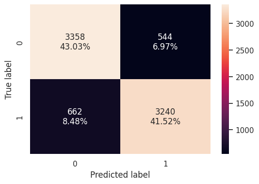

```python
# print confusion matrix on train set
plot_confusion_matrix(model_nn_with_adam_smote, X_train_smote, y_train_smote)
```

```
66/66 ━━━━━━━━━━━━━━━━━━━━ 0s 1ms/step
```

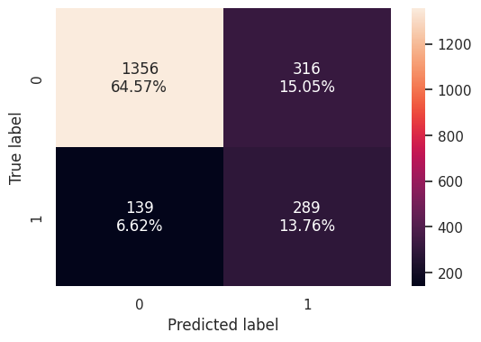

```python
# print confusion matrix on validation set
plot_confusion_matrix(model_nn_with_adam_smote, X_val, y_val)
```

### Neural Network with Balanced Data (by applying SMOTE), Adam Optimizer, and Dropout

```python
# Defining the batch size and # epochs upfront as we'll be using the same values for all models
epochs = 100
batch_size = 60
```

```python
# clears the current Keras session, resetting all layers and models previously created, freeing up memory and resources.
backend.clear_session()
```

```python
# Fixing the seed for random number generators
np.random.seed(2)

random.seed(2)

tf.random.set_seed(2)
```

```python
#Initializing the neural network
model_nn_with_adam_smote_drop = Sequential()

# Adding the first input layer with 32 neurons and relu as activation function
model_nn_with_adam_smote_drop.add(Dense(32, activation='relu', input_dim = X_train_smote.shape[1]))

# Complete the code to add dropout with ratio of 0.5 or any suitable value.
model_nn_with_adam_smote_drop.add(Dropout(0.5))

# Adding the second input layer with 16 neurons and relu as activation function
model_nn_with_adam_smote_drop.add(Dense(16, activation='relu'))

# Complete the code to add dropout with ratio of 0.3 or any suitable value.
model_nn_with_adam_smote_drop.add(Dropout(0.3))

# Adding the second input layer with 8 neurons and relu as activation function
model_nn_with_adam_smote_drop.add(Dense(8, activation='relu'))

# Adding the output input layer sigmoid as activation function
model_nn_with_adam_smote_drop.add(Dense(1, activation = 'sigmoid'))
```

Let's print the summary of the model

```python
#Printing the summary.
model_nn_with_adam_smote_drop.summary()
```

```
Model: "sequential"
```

```
┏━━━━━━━━━━━━━━━━━━━━━━━━━━━━━━━━━━━━━━┳━━━━━━━━━━━━━━━━━━━━━━━━━━━━━┳━━━━━━━━━━━━━━━━━┓
┃ Layer (type)                         ┃ Output Shape                ┃         Param # ┃
┡━━━━━━━━━━━━━━━━━━━━━━━━━━━━━━━━━━━━━━╇━━━━━━━━━━━━━━━━━━━━━━━━━━━━━╇━━━━━━━━━━━━━━━━━┩
│ dense (Dense)                        │ (None, 32)                  │             384 │
├──────────────────────────────────────┼─────────────────────────────┼─────────────────┤
│ dropout (Dropout)                    │ (None, 32)                  │               0 │
├──────────────────────────────────────┼─────────────────────────────┼─────────────────┤
│ dense_1 (Dense)                      │ (None, 16)                  │             528 │
├──────────────────────────────────────┼─────────────────────────────┼─────────────────┤
│ dropout_1 (Dropout)                  │ (None, 16)                  │               0 │
├──────────────────────────────────────┼─────────────────────────────┼─────────────────┤
│ dense_2 (Dense)                      │ (None, 8)                   │             136 │
├──────────────────────────────────────┼─────────────────────────────┼─────────────────┤
│ dense_3 (Dense)                      │ (None, 1)                   │               9 │
└──────────────────────────────────────┴─────────────────────────────┴─────────────────┘
```

```
 Total params: 1,057 (4.13 KB)
```

```
 Trainable params: 1,057 (4.13 KB)
```

```
 Non-trainable params: 0 (0.00 B)
```

```python
#Create an instance for Adam as the optimizer.
optimizer = tf.keras.optimizers.Adam(learning_rate=0.001)
```

```python
# Compile the model
model_nn_with_adam_smote_drop.compile(loss='binary_crossentropy', optimizer=optimizer, metrics=['recall'])
```

Training [Forward pass and Backpropagation]

Training the model

```python
# Now let's train the model using the below piece of code. We will use validation set for Validation.
start = time.time()
history_nn_with_adamsmotedrop = model_nn_with_adam_smote_drop.fit(
    X_train_smote, y_train_smote,
    batch_size=batch_size,
    validation_data=(X_val,y_val),
    epochs=epochs,
    verbose=1
)
end=time.time()
```

```
131/131 ━━━━━━━━━━━━━━━━━━━━ 5s 15ms/step - loss: 0.6785 - recall: 0.5991 - val_loss: 0.5880 - val_recall: 0.6706
131/131 ━━━━━━━━━━━━━━━━━━━━ 2s 2ms/step - loss: 0.6273 - recall: 0.6636 - val_loss: 0.5723 - val_recall: 0.6939
131/131 ━━━━━━━━━━━━━━━━━━━━ 0s 2ms/step - loss: 0.6008 - recall: 0.6853 - val_loss: 0.5724 - val_recall: 0.7079
131/131 ━━━━━━━━━━━━━━━━━━━━ 1s 2ms/step - loss: 0.6014 - recall: 0.6929 - val_loss: 0.5702 - val_recall: 0.7103
131/131 ━━━━━━━━━━━━━━━━━━━━ 1s 3ms/step - loss: 0.5966 - recall: 0.7045 - val_loss: 0.5692 - val_recall: 0.7126
131/131 ━━━━━━━━━━━━━━━━━━━━ 0s 3ms/step - loss: 0.5845 - recall: 0.7180 - val_loss: 0.5648 - val_recall: 0.7196
131/131 ━━━━━━━━━━━━━━━━━━━━ 1s 4ms/step - loss: 0.5736 - recall: 0.7126 - val_loss: 0.5649 - val_recall: 0.7033
131/131 ━━━━━━━━━━━━━━━━━━━━ 1s 4ms/step - loss: 0.5699 - recall: 0.7018 - val_loss: 0.5562 - val_recall: 0.7009
131/131 ━━━━━━━━━━━━━━━━━━━━ 0s 3ms/step - loss: 0.5728 - recall: 0.7001 - val_loss: 0.5636 - val_recall: 0.6963
131/131 ━━━━━━━━━━━━━━━━━━━━ 0s 2ms/step - loss: 0.5621 - recall: 0.7110 - val_loss: 0.5635 - val_recall: 0.6963
131/131 ━━━━━━━━━━━━━━━━━━━━ 1s 2ms/step - loss: 0.5597 - recall: 0.7109 - val_loss: 0.5606 - val_recall: 0.6846
131/131 ━━━━━━━━━━━━━━━━━━━━ 0s 2ms/step - loss: 0.5517 - recall: 0.7073 - val_loss: 0.5549 - val_recall: 0.6776
131/131 ━━━━━━━━━━━━━━━━━━━━ 0s 2ms/step - loss: 0.5507 - recall: 0.6984 - val_loss: 0.5498 - val_recall: 0.6682
131/131 ━━━━━━━━━━━━━━━━━━━━ 1s 2ms/step - loss: 0.5467 - recall: 0.6889 - val_loss: 0.5586 - val_recall: 0.6706
131/131 ━━━━━━━━━━━━━━━━━━━━ 1s 2ms/step - loss: 0.5432 - recall: 0.7054 - val_loss: 0.5567 - val_recall: 0.6636
131/131 ━━━━━━━━━━━━━━━━━━━━ 1s 2ms/step - loss: 0.5461 - recall: 0.7001 - val_loss: 0.5479 - val_recall: 0.6589
131/131 ━━━━━━━━━━━━━━━━━━━━ 1s 2ms/step - loss: 0.5419 - recall: 0.6971 - val_loss: 0.5559 - val_recall: 0.6612
131/131 ━━━━━━━━━━━━━━━━━━━━ 0s 2ms/step - loss: 0.5421 - recall: 0.7034 - val_loss: 0.5494 - val_recall: 0.6612
131/131 ━━━━━━━━━━━━━━━━━━━━ 0s 2ms/step - loss: 0.5413 - recall: 0.6949 - val_loss: 0.5509 - val_recall: 0.6659
131/131 ━━━━━━━━━━━━━━━━━━━━ 1s 2ms/step - loss: 0.5375 - recall: 0.6975 - val_loss: 0.5531 - val_recall: 0.6706
131/131 ━━━━━━━━━━━━━━━━━━━━ 0s 2ms/step - loss: 0.5349 - recall: 0.7136 - val_loss: 0.5507 - val_recall: 0.6706
131/131 ━━━━━━━━━━━━━━━━━━━━ 0s 2ms/step - loss: 0.5377 - recall: 0.7085 - val_loss: 0.5450 - val_recall: 0.6706
131/131 ━━━━━━━━━━━━━━━━━━━━ 0s 2ms/step - loss: 0.5364 - recall: 0.7117 - val_loss: 0.5447 - val_recall: 0.6776
131/131 ━━━━━━━━━━━━━━━━━━━━ 0s 2ms/step - loss: 0.5332 - recall: 0.7164 - val_loss: 0.5456 - val_recall: 0.6752
131/131 ━━━━━━━━━━━━━━━━━━━━ 1s 2ms/step - loss: 0.5371 - recall: 0.6970 - val_loss: 0.5479 - val_recall: 0.6776
131/131 ━━━━━━━━━━━━━━━━━━━━ 1s 2ms/step - loss: 0.5330 - recall: 0.7189 - val_loss: 0.5436 - val_recall: 0.6752
131/131 ━━━━━━━━━━━━━━━━━━━━ 0s 2ms/step - loss: 0.5392 - recall: 0.6922 - val_loss: 0.5423 - val_recall: 0.6752
131/131 ━━━━━━━━━━━━━━━━━━━━ 1s 2ms/step - loss: 0.5281 - recall: 0.7052 - val_loss: 0.5371 - val_recall: 0.6729
131/131 ━━━━━━━━━━━━━━━━━━━━ 1s 2ms/step - loss: 0.5274 - recall: 0.7029 - val_loss: 0.5336 - val_recall: 0.6659
131/131 ━━━━━━━━━━━━━━━━━━━━ 0s 2ms/step - loss: 0.5280 - recall: 0.7073 - val_loss: 0.5313 - val_recall: 0.6589
131/131 ━━━━━━━━━━━━━━━━━━━━ 1s 3ms/step - loss: 0.5308 - recall: 0.7036 - val_loss: 0.5472 - val_recall: 0.6916
131/131 ━━━━━━━━━━━━━━━━━━━━ 1s 4ms/step - loss: 0.5280 - recall: 0.7143 - val_loss: 0.5411 - val_recall: 0.6776
131/131 ━━━━━━━━━━━━━━━━━━━━ 1s 3ms/step - loss: 0.5322 - recall: 0.6992 - val_loss: 0.5433 - val_recall: 0.6893
131/131 ━━━━━━━━━━━━━━━━━━━━ 1s 4ms/step - loss: 0.5314 - recall: 0.7095 - val_loss: 0.5417 - val_recall: 0.6916
131/131 ━━━━━━━━━━━━━━━━━━━━ 1s 4ms/step - loss: 0.5248 - recall: 0.7106 - val_loss: 0.5368 - val_recall: 0.6822
131/131 ━━━━━━━━━━━━━━━━━━━━ 1s 3ms/step - loss: 0.5254 - recall: 0.7152 - val_loss: 0.5377 - val_recall: 0.6776
131/131 ━━━━━━━━━━━━━━━━━━━━ 0s 2ms/step - loss: 0.5289 - recall: 0.7122 - val_loss: 0.5376 - val_recall: 0.6846
131/131 ━━━━━━━━━━━━━━━━━━━━ 1s 2ms/step - loss: 0.5187 - recall: 0.7151 - val_loss: 0.5320 - val_recall: 0.6706
131/131 ━━━━━━━━━━━━━━━━━━━━ 0s 2ms/step - loss: 0.5186 - recall: 0.7142 - val_loss: 0.5300 - val_recall: 0.6799
131/131 ━━━━━━━━━━━━━━━━━━━━ 1s 2ms/step - loss: 0.5216 - recall: 0.7065 - val_loss: 0.5313 - val_recall: 0.6846
```

[output cut: 45 more lines]

```
131/131 ━━━━━━━━━━━━━━━━━━━━ 0s 2ms/step - loss: 0.4855 - recall: 0.7734 - val_loss: 0.4951 - val_recall: 0.7336
131/131 ━━━━━━━━━━━━━━━━━━━━ 1s 2ms/step - loss: 0.4883 - recall: 0.7623 - val_loss: 0.5032 - val_recall: 0.7453
131/131 ━━━━━━━━━━━━━━━━━━━━ 1s 3ms/step - loss: 0.4886 - recall: 0.7605 - val_loss: 0.4913 - val_recall: 0.7547
131/131 ━━━━━━━━━━━━━━━━━━━━ 1s 3ms/step - loss: 0.4898 - recall: 0.7663 - val_loss: 0.4900 - val_recall: 0.7477
131/131 ━━━━━━━━━━━━━━━━━━━━ 1s 4ms/step - loss: 0.4863 - recall: 0.7673 - val_loss: 0.5034 - val_recall: 0.7640
131/131 ━━━━━━━━━━━━━━━━━━━━ 1s 3ms/step - loss: 0.4817 - recall: 0.7646 - val_loss: 0.4976 - val_recall: 0.7570
131/131 ━━━━━━━━━━━━━━━━━━━━ 1s 4ms/step - loss: 0.4781 - recall: 0.7625 - val_loss: 0.4899 - val_recall: 0.7547
131/131 ━━━━━━━━━━━━━━━━━━━━ 0s 3ms/step - loss: 0.4779 - recall: 0.7664 - val_loss: 0.4962 - val_recall: 0.7523
131/131 ━━━━━━━━━━━━━━━━━━━━ 0s 2ms/step - loss: 0.4789 - recall: 0.7749 - val_loss: 0.4946 - val_recall: 0.7593
131/131 ━━━━━━━━━━━━━━━━━━━━ 1s 2ms/step - loss: 0.4848 - recall: 0.7825 - val_loss: 0.4908 - val_recall: 0.7547
131/131 ━━━━━━━━━━━━━━━━━━━━ 0s 2ms/step - loss: 0.4774 - recall: 0.7843 - val_loss: 0.4890 - val_recall: 0.7523
131/131 ━━━━━━━━━━━━━━━━━━━━ 0s 2ms/step - loss: 0.4792 - recall: 0.7816 - val_loss: 0.4923 - val_recall: 0.7593
131/131 ━━━━━━━━━━━━━━━━━━━━ 0s 2ms/step - loss: 0.4802 - recall: 0.7688 - val_loss: 0.4807 - val_recall: 0.7523
131/131 ━━━━━━━━━━━━━━━━━━━━ 0s 2ms/step - loss: 0.4776 - recall: 0.7746 - val_loss: 0.4959 - val_recall: 0.7710
131/131 ━━━━━━━━━━━━━━━━━━━━ 1s 2ms/step - loss: 0.4774 - recall: 0.7867 - val_loss: 0.4965 - val_recall: 0.7664
```

```python
print("Time taken in seconds ",end-start)
```

```
Time taken in seconds  53.621968269348145
```

**Let's plot Loss vs No. of Epochs**

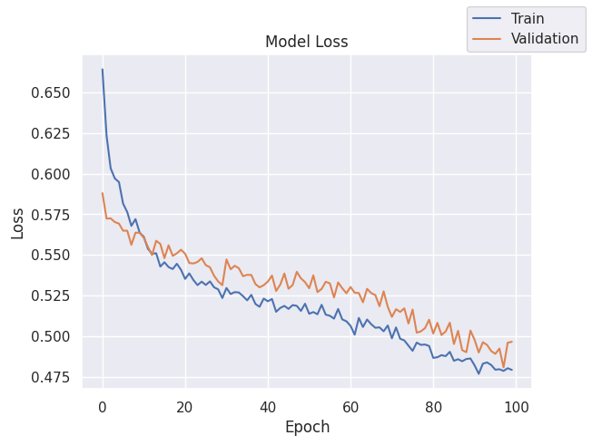

```python
plot(history_nn_with_adamsmotedrop,'loss')
```

- The train and validation loss are going down at a pace with some oscillations.

**Let's plot Recall vs No. of Epochs**

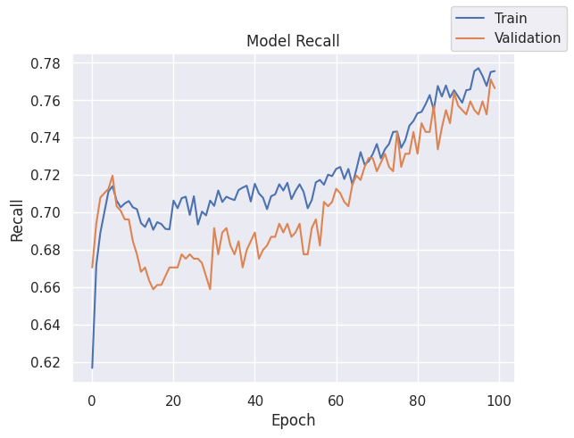

```python
plot(history_nn_with_adamsmotedrop,'recall')
```

- The train and validation Recalls are going up at a pace with some oscillations.

**Let's print Training performance:**

```python
# Calculating different metrics on train set
model_adamsmoredrop_train_perf  = model_performance_classification(
    model_nn_with_adam_smote_drop, X_train_smote, y_train_smote
)
print("Training performance:")
model_adamsmoredrop_train_perf
```

```
244/244 ━━━━━━━━━━━━━━━━━━━━ 1s 2ms/step
Training performance:
```

|  | Accuracy | Recall | Precision | F1 Score |
| --- | --- | --- | --- | --- |
| 0 | 0.803819 | 0.803819 | 0.804227 | 0.803753 |

**Let's print Validation performance:**

```python
# Calculating different metrics on train set
model_adamsmoredrop_val_perf  = model_performance_classification(
    model_nn_with_adam_smote_drop, X_val, y_val
)
print("Validation performance:")
model_adamsmoredrop_val_perf
```

```
66/66 ━━━━━━━━━━━━━━━━━━━━ 0s 2ms/step
Validation performance:
```

|  | Accuracy | Recall | Precision | F1 Score |
| --- | --- | --- | --- | --- |
| 0 | 0.77 | 0.77 | 0.832891 | 0.787941 |

- Train Recall score of ~0.80 and validation Recall score of ~0.77 indicate consistent performance of the model between training and validation datasets while calculating using weighted average.

**Classification Report**

```python
#Predicting the results using best as a threshold
y_train_pred = model_nn_with_adam_smote_drop.predict(X_train_smote)
y_train_pred = (y_train_pred > 0.5)

#Classification report on train set
cr_nn_with_adam_smote_drop_train = classification_report(y_train_smote, y_train_pred)
print(cr_nn_with_adam_smote_drop_train)
```

```
              precision    recall  f1-score   support

           0       0.82      0.79      0.80      3902
           1       0.79      0.82      0.81      3902

    accuracy                           0.80      7804
   macro avg       0.80      0.80      0.80      7804
weighted avg       0.80      0.80      0.80      7804
```

```python
#Predicting the results using best as a threshold
y_val_pred = model_nn_with_adam_smote_drop.predict(X_val)
y_val_pred = (y_val_pred > 0.5)

#Classification report on validation set
cr_nn_with_adam_smote_drop_val = classification_report(y_val, y_val_pred)
print(cr_nn_with_adam_smote_drop_val)
```

```
              precision    recall  f1-score   support

           0       0.93      0.77      0.84      1672
           1       0.46      0.77      0.58       428

    accuracy                           0.77      2100
   macro avg       0.69      0.77      0.71      2100
weighted avg       0.83      0.77      0.79      2100
```

```python
model_name = "Neural Netowrk with SMOTE, Adam & Dropout"

train_metric_df.loc[model_name] = recall_score(y_train_smote,y_train_pred)
valid_metric_df.loc[model_name] = recall_score(y_val,y_val_pred)
```

**Observations**

- For class 0, Train and validaiton recall is .79 and .77 respectively and well generalize
- For Class 1, Train and validaiton recall is .82 and .77 respectively and shows some overfitting.
- Model seems well generalize for both Class 0 and 1 while predecting recall.

**Let's print the Confusion matrix**

```
244/244 ━━━━━━━━━━━━━━━━━━━━ 0s 1ms/step
```

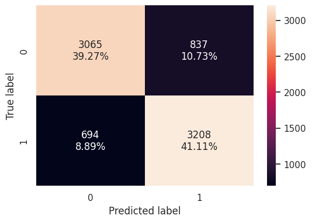

```python
# print confusion matrix on train set
plot_confusion_matrix(model_nn_with_adam_smote_drop, X_train_smote, y_train_smote)
```

```
66/66 ━━━━━━━━━━━━━━━━━━━━ 0s 1ms/step
```

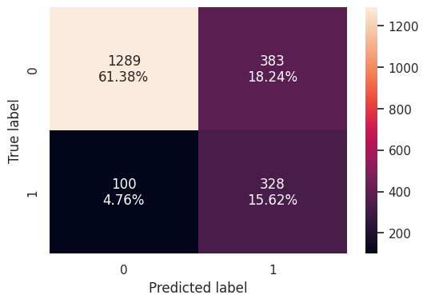

```python
# print confusion matrix on validation set
plot_confusion_matrix(model_nn_with_adam_smote_drop, X_val, y_val)
```

## Model Performance Comparison and Final Model Selection

```python
# training performance comparison

tuned_models_train_comp_df = pd.concat(
    [
        model_sgd_train_perf.T,
        model_adam_train_perf.T,
        model_adamdrop_train_perf.T,
        model_sgdsmote_train_perf.T,
        model_adamsmote_train_perf.T,
        model_adamsmoredrop_train_perf.T,
    ],
    axis=1,
)


tuned_models_train_comp_df.columns = [
    "SGD Optimizer",
    "Adam Optimizer",
    "Adam Optimizer with Dropout",
    "SGD Optimizer with SMOTE",
    "Adam Optimizer with SMOTE",
    "Adam Optimizer with SMOTE and Dropout",

]
```

```python
# Validation performance comparison

tuned_models_val_comp_df = pd.concat(
    [
        model_sgd_val_perf.T,
        model_adam_val_perf.T,
        model_adamdrop_val_perf.T,
        model_sgdsmote_val_perf.T,
        model_adamsmote_val_perf.T,
        model_adamsmoredrop_val_perf.T,
    ],
    axis=1,
)

tuned_models_val_comp_df.columns = [
    "SGD Optimizer",
    "Adam Optimizer",
    "Adam Optimizer with Dropout",
    "SGD Optimizer with SMOTE",
    "Adam Optimizer with SMOTE",
    "Adam Optimizer with SMOTE and Dropout",

]
```

```python
print("Models Training performance comparison:")
tuned_models_train_comp_df
```

```
Models Training performance comparison:
```

|  | SGD Optimizer | Adam Optimizer | Adam Optimizer with Dropout | SGD Optimizer with SMOTE | Adam Optimizer with SMOTE | Adam Optimizer with SMOTE and Dropout |
| --- | --- | --- | --- | --- | --- | --- |
| Accuracy | 0.811224 | 0.877755 | 0.866939 | 0.694516 | 0.845464 | 0.803819 |
| Recall | 0.811224 | 0.877755 | 0.866939 | 0.694516 | 0.845464 | 0.803819 |
| Precision | 0.796297 | 0.871166 | 0.860090 | 0.695136 | 0.845780 | 0.804227 |
| F1 Score | 0.752203 | 0.869311 | 0.852970 | 0.694273 | 0.845429 | 0.803753 |

```python
print("Models Validation performance comparison:")
tuned_models_val_comp_df
```

```
Models Validation performance comparison:
```

|  | SGD Optimizer | Adam Optimizer | Adam Optimizer with Dropout | SGD Optimizer with SMOTE | Adam Optimizer with SMOTE | Adam Optimizer with SMOTE and Dropout |
| --- | --- | --- | --- | --- | --- | --- |
| Accuracy | 0.800952 | 0.850000 | 0.857143 | 0.678571 | 0.783333 | 0.770000 |
| Recall | 0.800952 | 0.850000 | 0.857143 | 0.678571 | 0.783333 | 0.770000 |
| Precision | 0.760475 | 0.839655 | 0.846692 | 0.794640 | 0.819520 | 0.832891 |
| F1 Score | 0.739032 | 0.841797 | 0.845646 | 0.708873 | 0.795841 | 0.787941 |

**Conclusion if using weighted average to choose final Model**

```python
print("Training performance comparison")
train_metric_df
```

```
Training performance comparison
```

|  | recall |
| --- | --- |
| Neural Network with SGD | 0.117234 |
| Neural Network with Adam | 0.551102 |
| Neural Netowrk with Adam & Dropout | 0.466934 |
| Neural Netowrk with SMOTE and SGD | 0.722706 |
| Neural Netowrk with SMOTE and Adam | 0.830343 |
| Neural Netowrk with SMOTE, Adam & Dropout | 0.822142 |

```python
print("Validation set performance comparison")
valid_metric_df
```

```
Validation set performance comparison
```

|  | recall |
| --- | --- |
| Neural Network with SGD | 0.093458 |
| Neural Network with Adam | 0.509346 |
| Neural Netowrk with Adam & Dropout | 0.481308 |
| Neural Netowrk with SMOTE and SGD | 0.731308 |
| Neural Netowrk with SMOTE and Adam | 0.675234 |
| Neural Netowrk with SMOTE, Adam & Dropout | 0.766355 |

```python
train_metric_df - valid_metric_df
```

|  | recall |
| --- | --- |
| Neural Network with SGD | 0.023777 |
| Neural Network with Adam | 0.041756 |
| Neural Netowrk with Adam & Dropout | -0.014375 |
| Neural Netowrk with SMOTE and SGD | -0.008602 |
| Neural Netowrk with SMOTE and Adam | 0.155110 |
| Neural Netowrk with SMOTE, Adam & Dropout | 0.055787 |

**Conclusion for Final Model Selection while using recall mertic**

- **Neural Network with SMOTE, Adam & Dropout** is giving the highest recall on the validation set when comparing difference between Training and Validation recall.
- **Neural Network with SMOTE, Adam & Dropout** model is also shows well generalization since difference between Training and Validation recalls are ~5%.

### Test set final performance

**Let's print Test performance:**

```python
# Calculating different metrics on Test set for Adam Optimizer with Dropout	with original data set

model_adamdrop_test_perf = model_performance_classification(
    model_nn_with_adam_smote_drop, X_test, y_test
)

print("Test performance:")
model_adamdrop_test_perf
```

```
94/94 ━━━━━━━━━━━━━━━━━━━━ 0s 1ms/step
Test performance:
```

|  | Accuracy | Recall | Precision | F1 Score |
| --- | --- | --- | --- | --- |
| 0 | 0.765 | 0.765 | 0.832162 | 0.783848 |

- **Neural Network with SMOTE, Adam & Dropout** is giving .76 recall on the test data set while calculating for weighted average.

**Let's find the optimal threshold using the ROC-AUC curve**

```
94/94 ━━━━━━━━━━━━━━━━━━━━ 0s 1ms/step
```

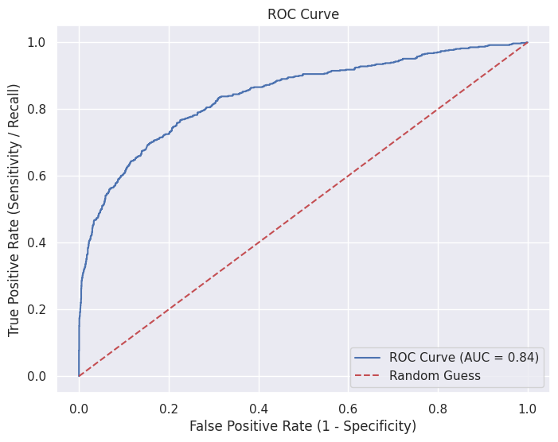

```
Optimal threshold: 0.5119040012359619
```

```python
y_test_pred = model_nn_with_adam_smote_drop.predict(X_test)

# Step 1: Compute the ROC curve
fpr, tpr, thresholds = roc_curve(y_test, y_test_pred)

auc = roc_auc_score(y_test, y_test_pred)

# Step 2: Compute the distance to the top-left corner (0,1)
distances = np.sqrt((1 - tpr)**2 + (fpr)**2)

# Step 3: Find the threshold that minimizes the distance
optimal_idx = np.argmin(distances)
optimal_threshold = thresholds[optimal_idx]

# Step 4: Plotting the ROC curve
plt.figure(figsize=(8, 6))
plt.plot(fpr, tpr, label=f'ROC Curve (AUC = {auc:.2f})', color='b')

# Plot the random guess line (45 degree line)
plt.plot([0, 1], [0, 1], linestyle='--', color='r', label='Random Guess')

# Set labels and title
plt.xlabel('False Positive Rate (1 - Specificity)')
plt.ylabel('True Positive Rate (Sensitivity / Recall)')
plt.title('ROC Curve')
plt.legend(loc='lower right')

# Display the plot
plt.grid(True)
plt.show()

print(f"\nOptimal threshold: {optimal_threshold}")
```

**Classification Report**

```python
#Predicting the results using best as a threshold
y_test_pred = (y_test_pred > 0.51)

#Classification report on validation set
cr_nn_with_adam_smote_drop_test = classification_report(y_test, y_test_pred)
print(cr_nn_with_adam_smote_drop_test)
```

```
              precision    recall  f1-score   support

           0       0.93      0.76      0.84      2389
           1       0.45      0.77      0.57       611

    accuracy                           0.77      3000
   macro avg       0.69      0.77      0.70      3000
weighted avg       0.83      0.77      0.78      3000
```

**Final Conclusion**

**Neural Network with SMOTE, Adam & Dropout** on Test data..

- For class 0, Test recall is .76
- For Class 1, Test recall is .77
- **Neural Network with SMOTE, Adam & Dropout** is giving the highest recall for i.e ~.77 on the test set for class 1 .

**Let's print the Confusion matrix**

```
94/94 ━━━━━━━━━━━━━━━━━━━━ 0s 1ms/step
```

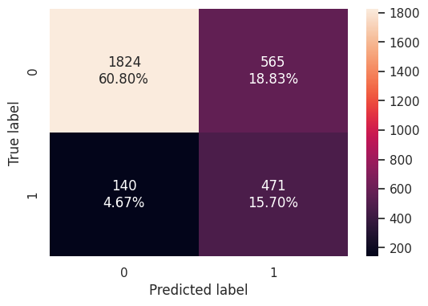

```python
# Print confusion matrix on Test set
plot_confusion_matrix(model_nn_with_adam_smote_drop, X_test, y_test)
```

## Actionable Insights and Business Recommendations

Actionable Insights:

- **Geography and Churn:** Customers from Germany are more likely to churn compared to those from France and Spain. Targeting this region with improved services and retention strategies may reduce churn.
- **Gender and Churn:** Female customers have a higher likelihood of leaving the bank compared to male customers. This may point to specific pain points or dissatisfaction that female customers experience more than males, requiring tailored retention strategies.
- **Customer Age:** Customers in the age group of 32 to 45 years represent the bulk of the customer base. However, age does not show a strong correlation with churn, suggesting that retention strategies shouldn't focus on age-specific initiatives alone.
- **Tenure Impact:** Customers with shorter tenures are more prone to churn. Offering early engagement programs, loyalty bonuses, and enhanced support for new customers (especially in their first few years) could help retain them.
- **Number of Products:** Customers with 3 or more products have a higher probability of leaving. The bank should monitor high-product users closely, as they might feel overwhelmed or may not need all the services. Offering personalized advice on optimizing their product use could prevent churn.
- **Inactive Members:** Inactive customers are significantly more likely to leave the bank. The bank should implement re-engagement campaigns for inactive members, such as personalized offers or reminders about the benefits of using bank services.
- **Credit Card Ownership:** The presence of a credit card does not significantly impact churn rates. Therefore, promoting credit cards as a retention tool may not be effective. However, other products or services might have more influence.
- **Credit Score Irrelevance:** Credit score does not appear to influence whether a customer leaves. Hence, using credit score alone to predict churn or target marketing efforts is not effective.
- **Balance and Salary Impact:** Neither the account balance nor the estimated salary significantly affects churn rates. Therefore, wealthier customers are not necessarily more likely to remain loyal, and these variables should not be the sole focus of retention strategies.

Business Recommendations:

1. **Geography-Specific Retention Programs:**
   - Focus on Germany by implementing targeted loyalty programs, offering specialized products, and providing improved customer service and feedback mechanisms.
2. **Female Customer Engagement:**
   - Conduct surveys or research to understand why female customers have a higher churn rate and tailor marketing or service improvements to address their needs.
   - Create gender-specific offers or campaigns to boost engagement.
3. **Enhanced Onboarding for New Customers:**
   - Provide personalized services and educational resources for customers with lower tenures to increase their engagement and reduce churn.
   - Implement loyalty programs or incentives for customers as they reach certain tenure milestones.
4. **Monitor and Assist High-Product Users:**
   - Regularly check in with customers who own multiple products to ensure they are satisfied with their services and not overwhelmed.
   - Offer product consolidation or optimization strategies to prevent them from leaving due to product overload.
5. **Re-Engagement for Inactive Members:**
   - Develop a program for inactive members that includes personalized reminders, offers for re-engagement, or exclusive services to encourage them to use the bank's services regularly.
   - Provide automated tools like spending analysis or financial health reports to inactive members as part of their bank account.
6. **Predictive Analytics for Early Churn Detection:**
   - Use the neural network model to predict and flag high-risk customers before they churn, focusing especially on customers with multiple products, shorter tenures, and inactive accounts.
   - Develop intervention strategies (like personalized offers or customer service interactions) based on these predictions.
7. **Personalized Product Recommendations:**
   - Leverage the data on product usage to offer customized product recommendations to customers. Ensure that recommendations are in line with their financial needs and usage patterns to prevent product overload and dissatisfaction.
8. **Customer Satisfaction and Feedback Mechanisms:**
   - Regularly collect feedback from customers (especially in the first few years) to address their concerns early on.
   - Develop a "Voice of the Customer" program to prioritize customer satisfaction and take proactive measures based on feedback.

By implementing these insights and recommendations, the bank can significantly reduce churn and improve customer satisfaction and loyalty.

Power Ahead